# Movie_Analysis

```python
# Import all the packages needed for my analysis

import pandas as pd
import numpy as np
import matplotlib.pyplot as plt
import seaborn as sns

%matplotlib inline
```

```python
df=pd.read_csv(r'C:\Users\DELL\OneDrive\Desktop\Movie project\DATA.csv')
```

```python
#print first five rows of the dataset
df.head()
```

|  | id | imdb_id | popularity | budget | revenue | original_title | cast | homepage | director | tagline | ... | overview | runtime | genres | production_companies | release_date | vote_count | vote_average | release_year | budget_adj | revenue_adj |
| --- | --- | --- | --- | --- | --- | --- | --- | --- | --- | --- | --- | --- | --- | --- | --- | --- | --- | --- | --- | --- | --- |
| 0 | 135397 | tt0369610 | 32.985763 | 150000000 | 1513528810 | Jurassic World | Chris Pratt\|Bryce Dallas Howard\|Irrfan Khan\|Vi... | http://www.jurassicworld.com/ | Colin Trevorrow | The park is open. | ... | Twenty-two years after the events of Jurassic ... | 124 | Action\|Adventure\|Science Fiction\|Thriller | Universal Studios\|Amblin Entertainment\|Legenda... | 6/9/15 | 5562 | 6.5 | 2015 | 1.379999e+08 | 1.392446e+09 |
| 1 | 76341 | tt1392190 | 28.419936 | 150000000 | 378436354 | Mad Max: Fury Road | Tom Hardy\|Charlize Theron\|Hugh Keays-Byrne\|Nic... | http://www.madmaxmovie.com/ | George Miller | What a Lovely Day. | ... | An apocalyptic story set in the furthest reach... | 120 | Action\|Adventure\|Science Fiction\|Thriller | Village Roadshow Pictures\|Kennedy Miller Produ... | 5/13/15 | 6185 | 7.1 | 2015 | 1.379999e+08 | 3.481613e+08 |
| 2 | 262500 | tt2908446 | 13.112507 | 110000000 | 295238201 | Insurgent | Shailene Woodley\|Theo James\|Kate Winslet\|Ansel... | http://www.thedivergentseries.movie/#insurgent | Robert Schwentke | One Choice Can Destroy You | ... | Beatrice Prior must confront her inner demons ... | 119 | Adventure\|Science Fiction\|Thriller | Summit Entertainment\|Mandeville Films\|Red Wago... | 3/18/15 | 2480 | 6.3 | 2015 | 1.012000e+08 | 2.716190e+08 |
| 3 | 140607 | tt2488496 | 11.173104 | 200000000 | 2068178225 | Star Wars: The Force Awakens | Harrison Ford\|Mark Hamill\|Carrie Fisher\|Adam D... | http://www.starwars.com/films/star-wars-episod... | J.J. Abrams | Every generation has a story. | ... | Thirty years after defeating the Galactic Empi... | 136 | Action\|Adventure\|Science Fiction\|Fantasy | Lucasfilm\|Truenorth Productions\|Bad Robot | 12/15/15 | 5292 | 7.5 | 2015 | 1.839999e+08 | 1.902723e+09 |
| 4 | 168259 | tt2820852 | 9.335014 | 190000000 | 1506249360 | Furious 7 | Vin Diesel\|Paul Walker\|Jason Statham\|Michelle ... | http://www.furious7.com/ | James Wan | Vengeance Hits Home | ... | Deckard Shaw seeks revenge against Dominic Tor... | 137 | Action\|Crime\|Thriller | Universal Pictures\|Original Film\|Media Rights ... | 4/1/15 | 2947 | 7.3 | 2015 | 1.747999e+08 | 1.385749e+09 |

5 rows × 21 columns

```python
#print Last two rows of the dataset
df.tail(2)
```

|  | id | imdb_id | popularity | budget | revenue | original_title | cast | homepage | director | tagline | ... | overview | runtime | genres | production_companies | release_date | vote_count | vote_average | release_year | budget_adj | revenue_adj |
| --- | --- | --- | --- | --- | --- | --- | --- | --- | --- | --- | --- | --- | --- | --- | --- | --- | --- | --- | --- | --- | --- |
| 10864 | 21449 | tt0061177 | 0.064317 | 0 | 0 | What's Up, Tiger Lily? | Tatsuya Mihashi\|Akiko Wakabayashi\|Mie Hama\|Joh... | NaN | Woody Allen | WOODY ALLEN STRIKES BACK! | ... | In comic Woody Allen's film debut, he took the... | 80 | Action\|Comedy | Benedict Pictures Corp. | 11/2/66 | 22 | 5.4 | 1966 | 0.000000 | 0.0 |
| 10865 | 22293 | tt0060666 | 0.035919 | 19000 | 0 | Manos: The Hands of Fate | Harold P. Warren\|Tom Neyman\|John Reynolds\|Dian... | NaN | Harold P. Warren | It's Shocking! It's Beyond Your Imagination! | ... | A family gets lost on the road and stumbles up... | 74 | Horror | Norm-Iris | 11/15/66 | 15 | 1.5 | 1966 | 127642.279154 | 0.0 |

2 rows × 21 columns

```python
# View dimensions of dataset-Number of rows and columns
df.shape
```

```
(10866, 21)
```

```python
# this returns the datatypes of the columns
df.dtypes
```

```
id                        int64
imdb_id                  object
popularity              float64
budget                    int64
revenue                   int64
original_title           object
cast                     object
homepage                 object
director                 object
tagline                  object
keywords                 object
overview                 object
runtime                   int64
genres                   object
production_companies     object
release_date             object
vote_count                int64
vote_average            float64
release_year              int64
budget_adj              float64
revenue_adj             float64
dtype: object
```

```python
#  A concise summary of the dataframe,including the number of non-null values in each column
df.info()
```

```
<class 'pandas.core.frame.DataFrame'>
RangeIndex: 10866 entries, 0 to 10865
Data columns (total 21 columns):
 #   Column                Non-Null Count  Dtype
---  ------                --------------  -----
 0   id                    10866 non-null  int64
 1   imdb_id               10856 non-null  object
 2   popularity            10866 non-null  float64
 3   budget                10866 non-null  int64
 4   revenue               10866 non-null  int64
 5   original_title        10866 non-null  object
 6   cast                  10790 non-null  object
 7   homepage              2936 non-null   object
 8   director              10822 non-null  object
 9   tagline               8042 non-null   object
 10  keywords              9373 non-null   object
 11  overview              10862 non-null  object
 12  runtime               10866 non-null  int64
 13  genres                10843 non-null  object
 14  production_companies  9836 non-null   object
 15  release_date          10866 non-null  object
 16  vote_count            10866 non-null  int64
 17  vote_average          10866 non-null  float64
 18  release_year          10866 non-null  int64
 19  budget_adj            10866 non-null  float64
 20  revenue_adj           10866 non-null  float64
dtypes: float64(4), int64(6), object(11)
memory usage: 1.7+ MB
```

## I have concluded:

1.'id', 'imdb_id' columns give us similar information, so i will delete the 'imdb_id' column from the dataframe. 2.'popularity', 'runtime', 'vote_average', 'vote_count','original_title', 'cast', 'director', 'Production companies', 'release_date', and 'release_year' columns are useful for my analysis. 3.The 'budget_adj' and 'revenue_adj' show the budget and revenue of the associated movie in terms of 2010 dollars, accounting for inflation over time. They are more useful than the non adjusted ones. So i will drop the non adjusted variables. 4.'homepage', 'tagline', 'keywords', 'overview' columns are not useful for my analysis so these columns would be deleted from the dataframe in the next data cleaning section.

```python
#As we have seen above, the dataset contain null values
# i will count total rows in each column which contain null values
df.isnull().sum()
```

```
id                         0
imdb_id                   10
popularity                 0
budget                     0
revenue                    0
original_title             0
cast                      76
homepage                7930
director                  44
tagline                 2824
keywords                1493
overview                   4
runtime                    0
genres                    23
production_companies    1030
release_date               0
vote_count                 0
vote_average               0
release_year               0
budget_adj                 0
revenue_adj                0
dtype: int64
```

```python
# print descriptive statistics for each column of data
df.describe()
```

|  | id | popularity | budget | revenue | runtime | vote_count | vote_average | release_year | budget_adj | revenue_adj |
| --- | --- | --- | --- | --- | --- | --- | --- | --- | --- | --- |
| count | 10866.000000 | 10866.000000 | 1.086600e+04 | 1.086600e+04 | 10866.000000 | 10866.000000 | 10866.000000 | 10866.000000 | 1.086600e+04 | 1.086600e+04 |
| mean | 66064.177434 | 0.646441 | 1.462570e+07 | 3.982332e+07 | 102.070863 | 217.389748 | 5.974922 | 2001.322658 | 1.755104e+07 | 5.136436e+07 |
| std | 92130.136561 | 1.000185 | 3.091321e+07 | 1.170035e+08 | 31.381405 | 575.619058 | 0.935142 | 12.812941 | 3.430616e+07 | 1.446325e+08 |
| min | 5.000000 | 0.000065 | 0.000000e+00 | 0.000000e+00 | 0.000000 | 10.000000 | 1.500000 | 1960.000000 | 0.000000e+00 | 0.000000e+00 |
| 25% | 10596.250000 | 0.207583 | 0.000000e+00 | 0.000000e+00 | 90.000000 | 17.000000 | 5.400000 | 1995.000000 | 0.000000e+00 | 0.000000e+00 |
| 50% | 20669.000000 | 0.383856 | 0.000000e+00 | 0.000000e+00 | 99.000000 | 38.000000 | 6.000000 | 2006.000000 | 0.000000e+00 | 0.000000e+00 |
| 75% | 75610.000000 | 0.713817 | 1.500000e+07 | 2.400000e+07 | 111.000000 | 145.750000 | 6.600000 | 2011.000000 | 2.085325e+07 | 3.369710e+07 |
| max | 417859.000000 | 32.985763 | 4.250000e+08 | 2.781506e+09 | 900.000000 | 9767.000000 | 9.200000 | 2015.000000 | 4.250000e+08 | 2.827124e+09 |

As it appears from the table shown above, 50% of the value in budget_adj and revenue_adj are zero value. Besides,the runtime minimum value is 0 which means that there could be a number of zero values in runtime.

To validate these findings, i will count total rows in each column which contain zero values.

```python
df.isin([0]).sum()
```

```
id                         0
imdb_id                    0
popularity                 0
budget                  5696
revenue                 6016
original_title             0
cast                       0
homepage                   0
director                   0
tagline                    0
keywords                   0
overview                   0
runtime                   31
genres                     0
production_companies       0
release_date               0
vote_count                 0
vote_average               0
release_year               0
budget_adj              5696
revenue_adj             6016
dtype: int64
```

As expected, there are 31 zero values rows in "runtime", 5696 zero values rows in "budget_adj" and 6016 zero value rows in "revenue_adj".

Thus, it is a huge amount of missing data for budget_adj and revenue_adj. In this case, dropping the missing rows of data is the best choice.

Otherwise, if it was just few rows, filling in it with the mean would have been a good idea, but using this technique in this situation would create a skewed analysis.

So, it is better to have less data with precise informations than large data with skewed results.

```python
#check for duplicates in the data
sum(df.duplicated())
```

```
1
```

```python
df[df.duplicated(keep=False)]
```

|  | id | imdb_id | popularity | budget | revenue | original_title | cast | homepage | director | tagline | ... | overview | runtime | genres | production_companies | release_date | vote_count | vote_average | release_year | budget_adj | revenue_adj |
| --- | --- | --- | --- | --- | --- | --- | --- | --- | --- | --- | --- | --- | --- | --- | --- | --- | --- | --- | --- | --- | --- |
| 2089 | 42194 | tt0411951 | 0.59643 | 30000000 | 967000 | TEKKEN | Jon Foo\|Kelly Overton\|Cary-Hiroyuki Tagawa\|Ian... | NaN | Dwight H. Little | Survival is no game | ... | In the year of 2039, after World Wars destroy ... | 92 | Crime\|Drama\|Action\|Thriller\|Science Fiction | Namco\|Light Song Films | 3/20/10 | 110 | 5.0 | 2010 | 30000000.0 | 967000.0 |
| 2090 | 42194 | tt0411951 | 0.59643 | 30000000 | 967000 | TEKKEN | Jon Foo\|Kelly Overton\|Cary-Hiroyuki Tagawa\|Ian... | NaN | Dwight H. Little | Survival is no game | ... | In the year of 2039, after World Wars destroy ... | 92 | Crime\|Drama\|Action\|Thriller\|Science Fiction | Namco\|Light Song Films | 3/20/10 | 110 | 5.0 | 2010 | 30000000.0 | 967000.0 |

2 rows × 21 columns

```python
# Returns the number of unique values in each column
df.nunique()
```

```
id                      10865
imdb_id                 10855
popularity              10814
budget                    557
revenue                  4702
original_title          10571
cast                    10719
homepage                 2896
director                 5067
tagline                  7997
keywords                 8804
overview                10847
runtime                   247
genres                   2039
production_companies     7445
release_date             5909
vote_count               1289
vote_average               72
release_year               56
budget_adj               2614
revenue_adj              4840
dtype: int64
```

Data Cleaning (Handling missing values and duplicate data: Removing unused information) In this section, i will try to handle the problem of missing values, duplicated data and format:

```python
# drop duplicates
df.drop_duplicates(inplace=True)
```

```python
# confirm correction by rechecking for duplicates in the data
sum(df.duplicated())
```

```
0
```

Drop unused columns I will drop columns that aren't relevant to my questions, such as: "imdb_id", "homepage", "overview", "tagline", "keywords". "Budget" and "revenue" will also be dropped as I will be using the adjusted ones showing the budget and revenue of the associated movie in terms of 2010 dollars, accounting for inflation over time.

```python
# drop unused columns
df.drop(['imdb_id','homepage','overview','tagline', 'keywords', 'budget','revenue'], axis=1, inplace=True)
```

```python
#confirm changes
df.head(1)
```

|  | id | popularity | original_title | cast | director | runtime | genres | production_companies | release_date | vote_count | vote_average | release_year | budget_adj | revenue_adj |
| --- | --- | --- | --- | --- | --- | --- | --- | --- | --- | --- | --- | --- | --- | --- |
| 0 | 135397 | 32.985763 | Jurassic World | Chris Pratt\|Bryce Dallas Howard\|Irrfan Khan\|Vi... | Colin Trevorrow | 124 | Action\|Adventure\|Science Fiction\|Thriller | Universal Studios\|Amblin Entertainment\|Legenda... | 6/9/15 | 5562 | 6.5 | 2015 | 1.379999e+08 | 1.392446e+09 |

Drop rows with null values

```python
# drop rows with any null values
df.dropna(inplace=True)
```

```python
# checks if any of columns in the data have null values - should print False
df.isnull().sum().any()
```

```
False
```

```python
# Convert 'release_date' type from str to datetime
df['release_date']=pd.to_datetime(df['release_date'])

df['release_date'].head()
```

```
0   2015-06-09
1   2015-05-13
2   2015-03-18
3   2015-12-15
4   2015-04-01
Name: release_date, dtype: datetime64[ns]
```

```python
# confirm correction by rechecking info function
df.info()
```

```
<class 'pandas.core.frame.DataFrame'>
Index: 9772 entries, 0 to 10865
Data columns (total 14 columns):
 #   Column                Non-Null Count  Dtype
---  ------                --------------  -----
 0   id                    9772 non-null   int64
 1   popularity            9772 non-null   float64
 2   original_title        9772 non-null   object
 3   cast                  9772 non-null   object
 4   director              9772 non-null   object
 5   runtime               9772 non-null   int64
 6   genres                9772 non-null   object
 7   production_companies  9772 non-null   object
 8   release_date          9772 non-null   datetime64[ns]
 9   vote_count            9772 non-null   int64
 10  vote_average          9772 non-null   float64
 11  release_year          9772 non-null   int64
 12  budget_adj            9772 non-null   float64
 13  revenue_adj           9772 non-null   float64
dtypes: datetime64[ns](1), float64(4), int64(4), object(5)
memory usage: 1.1+ MB
```

```python
# Final number of movies
rows, col = df.shape
print('After cleaning, we now have only {} entries of movies.'.format(rows))
```

```
After cleaning, we now have only 9772 entries of movies.
```

```python
# save progress for the next session
df.to_csv('tmdb-movies-cleaned.csv', index=False)
```

# Exploratory Data Analysis

# Question 1: What kinds of properties are associated with most and less successful movies?

To answer this question, I will first calculate the financial benefit realized by each movie by subtracting the budget adjusted (accounting for inflation over time) from the revenue adjusted. We say that there is a profit when revenue generated from a movie exceeds the expenses, costs, and taxes involved in sustaining the activity in question, and vice versa for losses.

# Calculate Movies profit or loss

```python
# calculate profit/ loss(losses when there are negative values) of each movie, by substracting the budget_adj from the revenue_adj of each movie
df['profit']=df['revenue_adj']-df['budget_adj']

#show dataset first two rows
df.head(2)
```

|  | id | popularity | original_title | cast | director | runtime | genres | production_companies | release_date | vote_count | vote_average | release_year | budget_adj | revenue_adj | profit |
| --- | --- | --- | --- | --- | --- | --- | --- | --- | --- | --- | --- | --- | --- | --- | --- |
| 0 | 135397 | 32.985763 | Jurassic World | Chris Pratt\|Bryce Dallas Howard\|Irrfan Khan\|Vi... | Colin Trevorrow | 124 | Action\|Adventure\|Science Fiction\|Thriller | Universal Studios\|Amblin Entertainment\|Legenda... | 2015-06-09 | 5562 | 6.5 | 2015 | 1.379999e+08 | 1.392446e+09 | 1.254446e+09 |
| 1 | 76341 | 28.419936 | Mad Max: Fury Road | Tom Hardy\|Charlize Theron\|Hugh Keays-Byrne\|Nic... | George Miller | 120 | Action\|Adventure\|Science Fiction\|Thriller | Village Roadshow Pictures\|Kennedy Miller Produ... | 2015-05-13 | 6185 | 7.1 | 2015 | 1.379999e+08 | 3.481613e+08 | 2.101614e+08 |

# Create a function to extract the min and the max values

So as to facilitate the answer to some questions, i will create a function that willextract the min and the max simultaneously, by using the idxmin()/idxmax() function to get the row label of the minimum/maximum value

```python
# Create a minmax function by using idxmin()/idxmax() function to get the row label of the minimum/maximum value.

def min_max(x):
    # calculate maximum value
    highest = df[x].idxmax()
    highest_details = pd.DataFrame(df.loc[highest])

    # calculate minimum value
    lowest = df[x].idxmin()
    lowest_details = pd.DataFrame(df.loc[lowest])

    print('Movie which has highest '+x+' : ', df['original_title'][highest])
    print('Movie which has lowest '+x+' : ', df['original_title'][lowest])

    return pd.concat([highest_details, lowest_details], axis=1)
```

# Which Movie had the highest or lowest profit?

```python
# Find movies that make the highest and lowest profit by using the min_max function constructed above
min_max('profit')
```

```
Movie which has highest profit :  Star Wars
Movie which has lowest profit :  The Warrior's Way
```

|  | 1329 | 2244 |
| --- | --- | --- |
| id | 11 | 46528 |
| popularity | 12.037933 | 0.25054 |
| original_title | Star Wars | The Warrior's Way |
| cast | Mark Hamill\|Harrison Ford\|Carrie Fisher\|Peter ... | Kate Bosworth\|Jang Dong-gun\|Geoffrey Rush\|Dann... |
| director | George Lucas | Sngmoo Lee |
| runtime | 121 | 100 |
| genres | Adventure\|Action\|Science Fiction | Adventure\|Fantasy\|Action\|Western\|Thriller |
| production_companies | Lucasfilm\|Twentieth Century Fox Film Corporation | Boram Entertainment Inc. |
| release_date | 1977-03-20 00:00:00 | 2010-12-02 00:00:00 |
| vote_count | 4428 | 74 |
| vote_average | 7.9 | 6.4 |
| release_year | 1977 | 2010 |
| budget_adj | 39575591.358274 | 425000000.0 |
| revenue_adj | 2789712242.27745 | 11087569.0 |
| profit | 2750136650.919176 | -413912431.0 |

According to our sample, the first column shows the movie with the highest profit and the second column shows the movie with the lowest profit.

# Which year the movie industry made the highest profit?

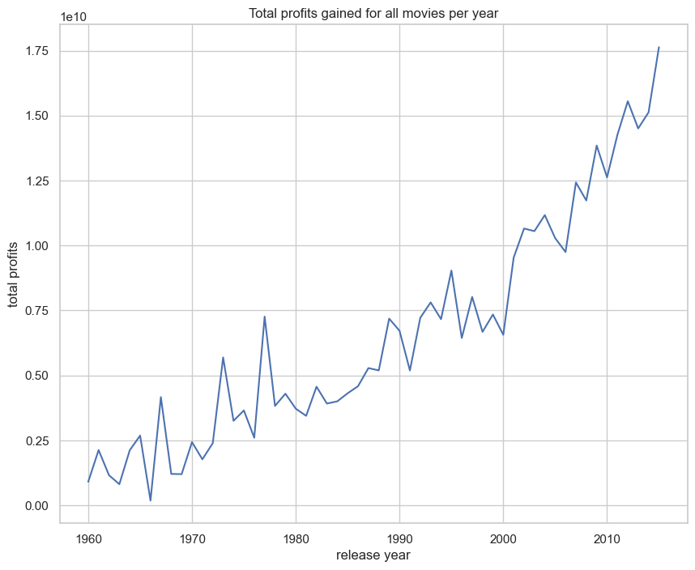

```
The movie industry made the highest profit in 2015 .
```

```python
#calculate Total Profits gained for all movies per year
profit_peryear = df.groupby('release_year')['profit'].sum()

ax = profit_peryear.plot(stacked=True, figsize=(10,8));
ax.set(xlabel='release year', ylabel='total profits', title = 'Total profits gained for all movies per year')
plt.show()

max_profit= profit_peryear.idxmax()

print('The movie industry made the highest profit in', max_profit,'.')
```

# Which month the movie industry made the highest profit?

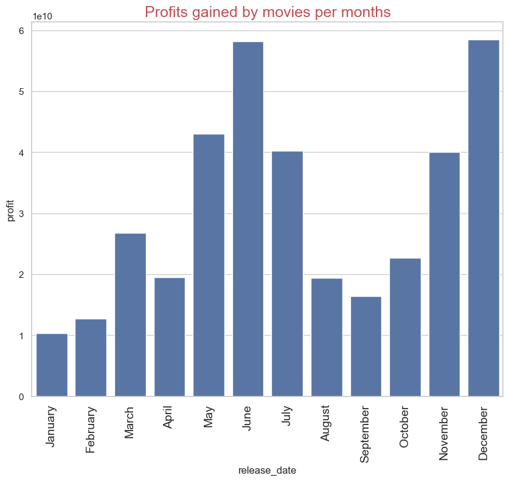

```python
releasedate_index = df.set_index('release_date')

# extract month from the release data index
groupby_index = releasedate_index.groupby([(releasedate_index.index.month)])

# Monthly data
profit_permonth = groupby_index['profit'].sum()
profit_permonth = pd.DataFrame(profit_permonth)

#plot our data
sns.set(rc={'figure.figsize':(10,8)}, style="whitegrid")

profit_permonth_bar = sns.barplot(x = profit_permonth.index, y = profit_permonth['profit'], data = profit_permonth)

profit_permonth_bar.axes.set_title('Profits gained by movies per months', color="r", fontsize = 18)

month_list = ['January', 'February', 'March', 'April', 'May', 'June', 'July', 'August', 'September', 'October', 'November', 'December']

#rotate the x-axis text
profit_permonth_bar.set_xticklabels(month_list, rotation = 90, size = 14);
```

We can say that june and december are the months when movies have gained the highest profits. These findings show the effect of holidays and festivities on the movie profitability.

# Do popular movies get higher profit?

[output not shown]

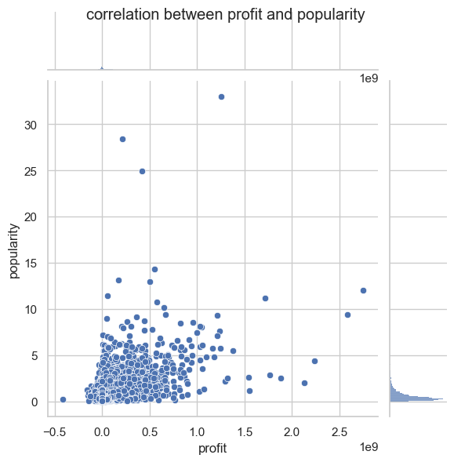

```python
#correlation between profit and popularity
fig1 = sns.jointplot(x = "profit", y = "popularity", kind = "scatter", data = df)
fig1.fig.suptitle('correlation between profit and popularity');

data_corr = df.corr()
print("Correlation Between profit And popularity : ",data_corr.loc['profit','popularity'])
```

```python
# find movies that make the highest and lowest budget
min_max('budget_adj')
```

[output not shown]

The first column shows the movie with the highest budget(adjusted) and the second column shows the movie with the lowest budget.

Unfortunatly, the warrior's way which is the less profitable movie has the highest budget in all and very low popularity, spending over $425 million dollars.

# What is the statistical relationship between budget and profit?

```python
#Correlation between budget and profit

fig2 = sns.jointplot(data = df, x = 'budget_adj', y = 'profit', kind = 'scatter')
fig2.fig.suptitle('correlation between budget and profit');
print("Correlation Between profit And Budget : ",data_corr.loc['profit','budget_adj'])
```

[output not shown]

# Do movies with highest budget get highest rating?

```python
#Correlation between budget and rating

fig3 = sns.jointplot(data = df, x = 'budget_adj', y = 'vote_average', kind = 'scatter')
fig3.fig.suptitle('orrelation between votes and budget');
print("Correlation Between vote rating And Budget : ",data_corr.loc['vote_average','budget_adj'])
```

[output not shown]

# Which Movie had the highest or lowest revenue?

```python
# find movies that make the highest and lowest revenue
min_max('revenue_adj')
```

[output not shown]

The first column shows the highest revenue made by a movie and the second one shows the movie with the lowest revenue .

# Is there any statistical relationship between revenue and profit/ revenue and budget?

```python
#correlation
fig4 = sns.jointplot(x = "budget_adj", y = "revenue_adj", kind = "scatter", data = df)

fig4.fig.suptitle('correlation between budget and revenue');


fig5 = sns.jointplot(x = "profit", y = "revenue_adj", kind = "scatter", data = df)

fig5.fig.suptitle('correlation between profit and revenue');

print("Correlation Between revenue And Budget : ",data_corr.loc['revenue_adj','budget_adj'])
print("Correlation Between revenue And profit : ",data_corr.loc['revenue_adj','profit'])
```

[output not shown]

It is very apparent that there is a very high and positive correlation between profit and revenue . So companies that have larger revenues could have higher profits. Also, there is a positive and significative correlation between revenue and budget. It means that there is a good possibility that movies with higher expenses result in better revenues. To dig even deeper, causality tests should be carried out.

# What is the movie length most liked by the audience?

```python
# Rutime film most liked by audience
run_pop=df.groupby('runtime')['popularity'].mean()
run_pop.plot(figsize = (10,8))
#title
plt.title("Runtime most liked by audience",fontsize=14)
plt.xlabel('Runtime',fontsize = 13)
plt.ylabel('Popularity',fontsize = 13)
#max_value
max_run= run_pop.idxmax()

print('Rutime most liked by audience', max_run, 'minutes.')
```

[output not shown]

# Which Movie is high or less rated?

```python
# find movies that make the most and less Vote
min_max('vote_average')
```

[output not shown]

# Do high rated movies get higher profit?

```python
#correlation
fig6 = sns.jointplot(x = "profit", y = "vote_average", kind = "scatter", data = df)

fig6.fig.suptitle('correlation between profit and votes');

print("Correlation Between profit And votes : ",data_corr.loc['profit','vote_average'])
```

[output not shown]

According to the correlation test, there is a weak statistical relationship between the profit and the movie rating.

# What are the Top 10 movies according to different features (Profit, budget, revenue, popularity, votes)?

```python
#Top Movies based on different features
Top_revenue = df[["original_title", "revenue_adj"]]
Top_budget = df[['original_title','budget_adj']]
Top_profit = df[["original_title", "profit"]]
Top_popularity = df[['original_title','popularity']]
```

# Top 10 most profitable movies

```python
# Plot the top 10 most profitable movies
sns.set(rc={'figure.figsize':(10,8)}, style="whitegrid")

# Correct usage of sns.barplot with keyword arguments
ax = sns.barplot(
    x="original_title",
    y="profit",
    data=Top_profit.sort_values(by="profit", ascending=False).head(10))

# Rotate x-axis' text for better readability
ax.set(xlabel='Original movie title', ylabel='Profit', title='Top 10 most profitable movies')
plt.xticks(rotation=90)

# Display the plot
plt.show()
```

[output not shown]

# Top 10 movies based on gained revenue

```python
# Plot the top 10 movies based on revenue
sns.set(rc={'figure.figsize':(10,8)}, style="whitegrid")

# Correct usage of sns.barplot with keyword arguments
ax = sns.barplot(
    x="original_title",
    y="revenue_adj",
    data=Top_revenue.sort_values(by="revenue_adj", ascending=False).head(10))

# Rotate x-axis' text for better readability
ax.set(xlabel='Original movie title', ylabel='Revenue', title='Top 10 movies based on revenue')
plt.xticks(rotation=90)

# Display the plot
plt.show()
```

[output not shown]

# Top 10 most expensive movies

```python
# Plot the top 10 movies based on budget
sns.set(rc={'figure.figsize':(10,8)}, style="whitegrid")

# Correct usage of sns.barplot with keyword arguments
ax = sns.barplot(
    x="original_title",
    y="budget_adj",
    data=Top_budget.sort_values(by="budget_adj", ascending=False).head(10))

# Rotate x-axis' text for better readability
ax.set(xlabel='Original movie title', ylabel='Budget', title='Top 10 movies based on budget')
plt.xticks(rotation=90)

# Display the plot
plt.show()
```

[output not shown]

# Top 10 most popular movies

```python
# Plot the top 10 most popular movies
sns.set(rc={'figure.figsize':(10,8)}, style="whitegrid")

# Correct usage of sns.barplot with keyword arguments
ax = sns.barplot(
    x="original_title",
    y="popularity",
    data=Top_popularity.sort_values(by="popularity", ascending=False).head(10))

# Rotate x-axis' text for better readability
ax.set(xlabel='Original movie title', ylabel='Popularity', title='Top 10 most popular movies')
plt.xticks(rotation=90)

# Display the plot
plt.show()
```

[output not shown]

# Which genres are most popular and profitable, overall and overtime?

## Number of movies produced per genre

```python
# split the genres  from combined value into single genre value
df_split = df.assign(genres = df['genres'].str.split('|')).explode('genres')

df_split.head(2)
```

[output not shown]

```python
df_split['genres'].value_counts(ascending = False).plot(kind='bar',figsize = (10,8),color='g');

plt.title('Movies by Genre, 1960-2015', size=18)
plt.xlabel('Genres', size=12)
plt.ylabel('Number of occurance')
sns.set_style("whitegrid")
```

[output not shown]

As we can see, Drama movies are the most frequent movie genre. The top 5 dominant movie genres all over these years (1960 - 2015) are Drama, Comedy,Thriller, Action and Adventure.

# Which genres are more profitable overall?

```python
# Calculate profitability of each genre
profit_and_genres_df = df_split[['genres', 'profit']]

# Group by genres and calculate the mean profit for each genre
mean_profit_vs_genre_df = profit_and_genres_df.groupby('genres', as_index=False)['profit'].mean()

# Sort the result based on profit in descending order
mean_profit_vs_genre_df = mean_profit_vs_genre_df.sort_values(by='profit', ascending=False)

# Display the top genres by mean profit in a table format
mean_profit_vs_genre_df.head()
```

[output not shown]

```python
#plot
mean_profit_vs_genre_df['profit'].plot(stacked=False, kind='barh', figsize = (10,8),color='g');
plt.title('Genres classification by profit', size=18)
plt.xlabel('profit made', size=12);
sns.set_style("whitegrid")
```

[output not shown]

Even that, "Drama" genres are the most frequent genre produced overall, but the most profitable one is "Animation". So the top 5 most profitable genres of movies from 1960 to 2015 are : Animation, Adventure, Family, Fantasy, Science Fiction.

# Which genres are more profitable from year to year?

In this part, i will focus on the top 5 most profitable genres found in the last part to investigate which is the more profitable genre from year to year.

```python
#plot 5 most profitable genres over time

genres_peryear_df = df_split[['original_title', 'profit', 'genres','release_year','popularity']]

genre_profit_df = genres_peryear_df.groupby(['genres', 'release_year'], as_index=False)['profit'].mean()
fig,ax = plt.subplots(figsize=(10,8))

for genres in ['Animation','Adventure','Family', 'Fantasy', 'Science Fiction']:
    ax.plot(genre_profit_df[genre_profit_df.genres==genres].release_year,
            genre_profit_df[genre_profit_df.genres==genres].profit,label=genres)

ax.set_xlabel("release year")
ax.set_ylabel("profit")
plt.title('Profit made by genres from 1960 to 2015')
plt.show()
```

[output not shown]

Most profitable Genres varies quite a lot from year to year and have known an upward in recent years. In 2015, Science fiction is the most profitable in 2015 followed by adventure in the second position and family in the third position.

# Which genres are more popular overall?

```python
# Calculate popularity of each genre
popular_and_genres_df = df_split[['genres', 'popularity']]

# Group by genres and calculate the mean popularity for each genre
mean_popular_vs_genre_df = popular_and_genres_df.groupby('genres', as_index=False)['popularity'].mean()

# Sort the result based on popularity in descending order
mean_popular_vs_genre_df = mean_popular_vs_genre_df.sort_values(by='popularity', ascending=False)

# Display the top genres by mean popularity in a table format
mean_popular_vs_genre_df.head()
```

[output not shown]

```python
#plot
mean_popular_vs_genre_df['popularity'].plot(stacked=False, kind='barh', figsize = (8,8),color='g');
plt.title('Genres classification by popularity', size=18)
plt.xlabel('popularity', size=12);
sns.set_style("whitegrid")
```

[output not shown]

The top 5 most popular genres of movies from 1960 to 2015 are : Adventure, Science fiction, Fantasy, animation, action.